# WEEK13COREIP

Silvia Wakasa Barasa

9/7/2021

```r
library(knitr)
knitr::opts_chunk$set(echo = TRUE,eval=TRUE)
```

# **Research Question**

A Kenyan entrepreneur has created an online cryptography course and would want to advertise it on her blog. She currently targets audiences originating from various countries. In the past, she ran ads to advertise a related course on the same blog and collected data in the process. She would now like to employ your services as a Data Science Consultant to help her identify which individuals are most likely to click on her ads.

## **1. Defining the Question**

### **1.1. Specifying the data analytic objective**

Our main aim is to do thorough exploratory data analysis for univariate and bivariate data and come up with recommendations for our client.

### **1.2. Defining the metric for success**

We aim to build elaborate visualizations for univariate and bivariate analysis

### **1.3. Recording the Experimental Design**

- Loading the data
- Checking the data
- Tidying the data
- Univariate Analysis
- Bivariate Analysis
- Challenging the solution
- Recommendations
- Follow up questions

### **1.4. Data Relevance**

The data provided was relevant for our analysis.

## *2.Loading the required libraries*

## *Loading Data*

```r
df = read.csv('http://bit.ly/IPAdvertisingData')
View(df)
```

## *Checking the data*

### *viewing the top 6 entries*

```r
head(df)
```

```
##   Daily.Time.Spent.on.Site Age Area.Income Daily.Internet.Usage
## 1                    68.95  35    61833.90               256.09
## 2                    80.23  31    68441.85               193.77
## 3                    69.47  26    59785.94               236.50
## 4                    74.15  29    54806.18               245.89
## 5                    68.37  35    73889.99               225.58
## 6                    59.99  23    59761.56               226.74
##                           Ad.Topic.Line           City Male    Country
## 1    Cloned 5thgeneration orchestration    Wrightburgh    0    Tunisia
## 2    Monitored national standardization      West Jodi    1      Nauru
## 3      Organic bottom-line service-desk       Davidton    0 San Marino
## 4 Triple-buffered reciprocal time-frame West Terrifurt    1      Italy
## 5         Robust logistical utilization   South Manuel    0    Iceland
## 6       Sharable client-driven software      Jamieberg    1     Norway
##             Timestamp Clicked.on.Ad
## 1 2016-03-27 00:53:11             0
## 2 2016-04-04 01:39:02             0
## 3 2016-03-13 20:35:42             0
## 4 2016-01-10 02:31:19             0
## 5 2016-06-03 03:36:18             0
## 6 2016-05-19 14:30:17             0
```

### *Viewing the bottom 6 entries*

```r
tail(df)
```

```
##      Daily.Time.Spent.on.Site Age Area.Income Daily.Internet.Usage
## 995                     43.70  28    63126.96               173.01
## 996                     72.97  30    71384.57               208.58
## 997                     51.30  45    67782.17               134.42
## 998                     51.63  51    42415.72               120.37
## 999                     55.55  19    41920.79               187.95
## 1000                    45.01  26    29875.80               178.35
##                             Ad.Topic.Line          City Male
## 995         Front-line bifurcated ability  Nicholasland    0
## 996         Fundamental modular algorithm     Duffystad    1
## 997       Grass-roots cohesive monitoring   New Darlene    1
## 998          Expanded intangible solution South Jessica    1
## 999  Proactive bandwidth-monitored policy   West Steven    0
## 1000      Virtual 5thgeneration emulation   Ronniemouth    0
##                     Country           Timestamp Clicked.on.Ad
## 995                 Mayotte 2016-04-04 03:57:48             1
## 996                 Lebanon 2016-02-11 21:49:00             1
## 997  Bosnia and Herzegovina 2016-04-22 02:07:01             1
## 998                Mongolia 2016-02-01 17:24:57             1
## 999               Guatemala 2016-03-24 02:35:54             0
## 1000                 Brazil 2016-06-03 21:43:21             1
```

### *Viewing the data types of our columns*

```r
lapply(df,class)
```

```
## $Daily.Time.Spent.on.Site
## [1] "numeric"
##
## $Age
## [1] "integer"
##
## $Area.Income
## [1] "numeric"
##
## $Daily.Internet.Usage
## [1] "numeric"
##
## $Ad.Topic.Line
## [1] "character"
##
## $City
## [1] "character"
##
## $Male
## [1] "integer"
##
## $Country
## [1] "character"
##
## $Timestamp
## [1] "character"
##
## $Clicked.on.Ad
## [1] "integer"
```

## *3. Tidying the data*

### *Checking for null values*

```r
colSums(is.na(df))
```

```
## Daily.Time.Spent.on.Site                      Age              Area.Income
##                        0                        0                        0
##     Daily.Internet.Usage            Ad.Topic.Line                     City
##                        0                        0                        0
##                     Male                  Country                Timestamp
##                        0                        0                        0
##            Clicked.on.Ad
##                        0
```

### *Checking for duplicates*

```r
sum(duplicated(df))
```

```
## [1] 0
```

```r
sum(!duplicated(df))
```

```
## [1] 1000
```

There are no duplicates in our data

### *checking for outliers*

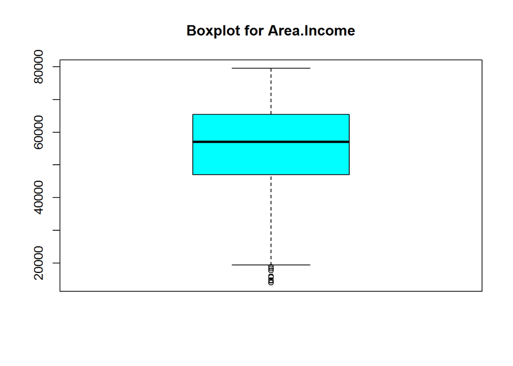

```r
boxplot(df$`Area.Income`,main="Boxplot for Area.Income",col = "cyan")
```

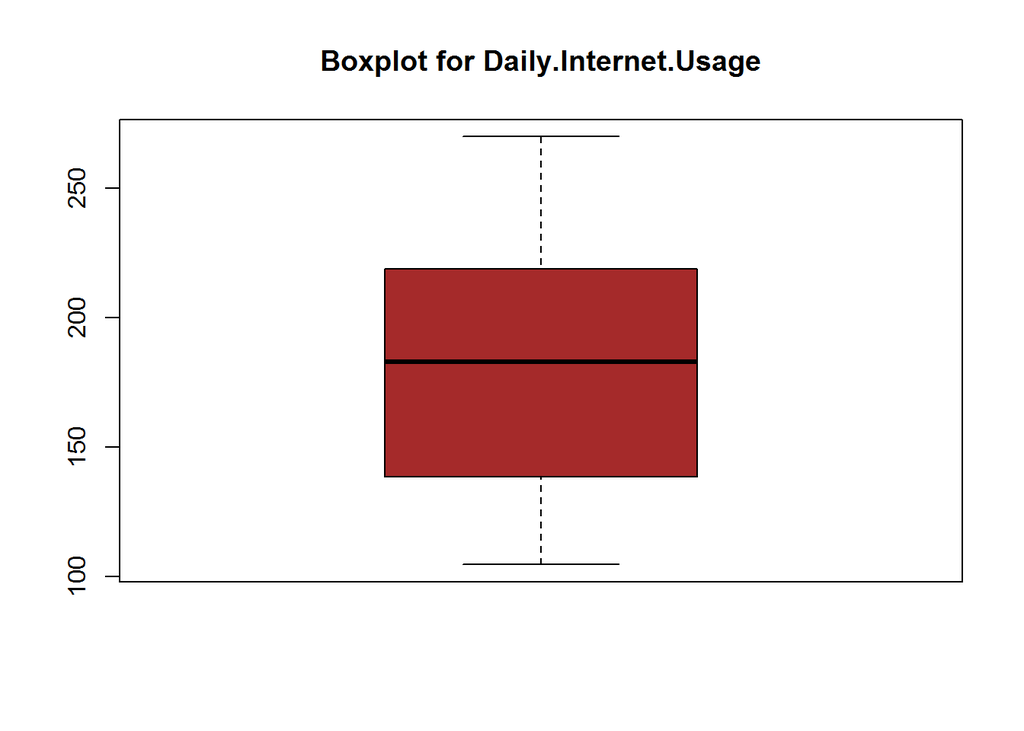

```r
boxplot(df$`Daily.Internet.Usage`,main="Boxplot for Daily.Internet.Usage",col="brown")
```

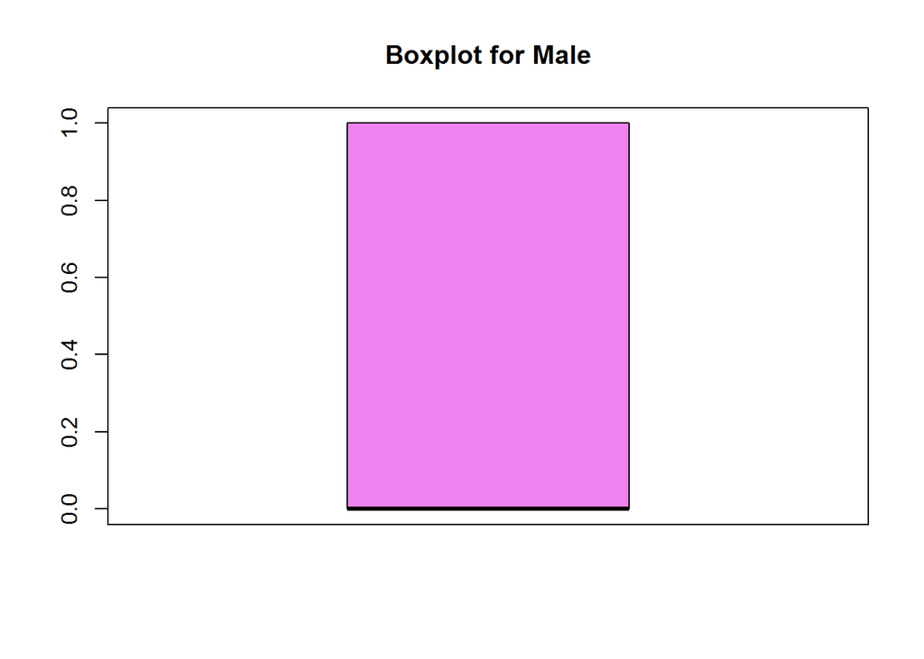

```r
boxplot(df$`Male`,main="Boxplot for Male",col = "violet")
```

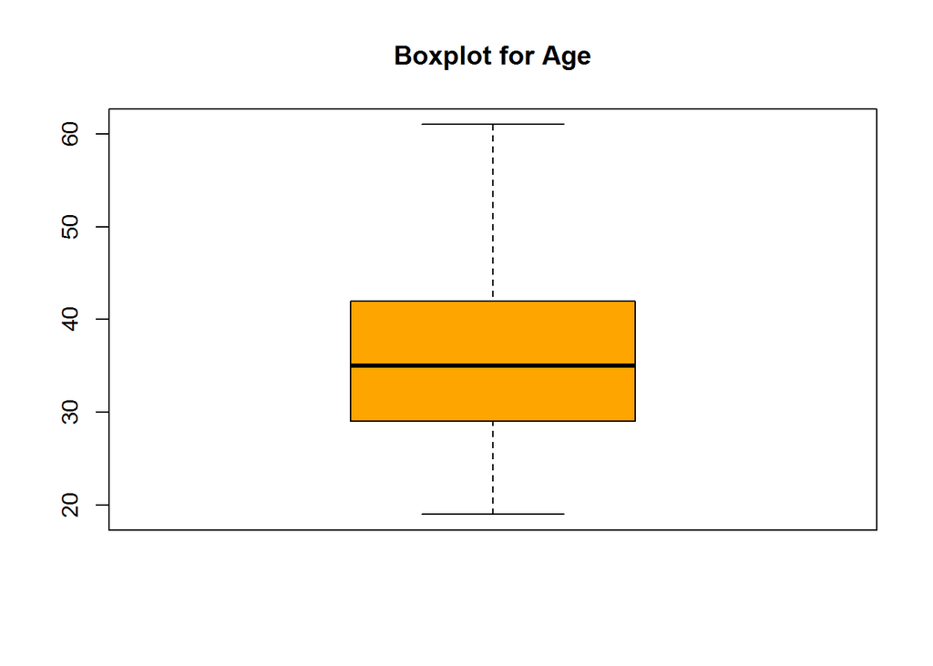

```r
boxplot(df$`Age`,main="Boxplot for Age",col = "orange")
```

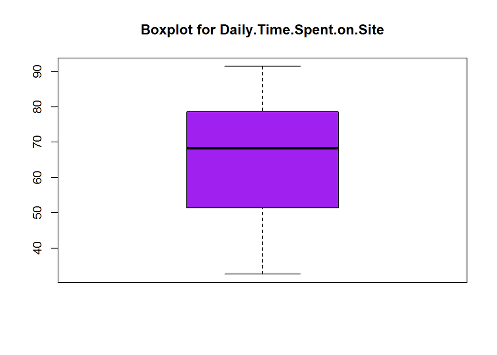

```r
boxplot(df$`Daily.Time.Spent.on.Site`,main="Boxplot for Daily.Time.Spent.on.Site",col = "purple")
```

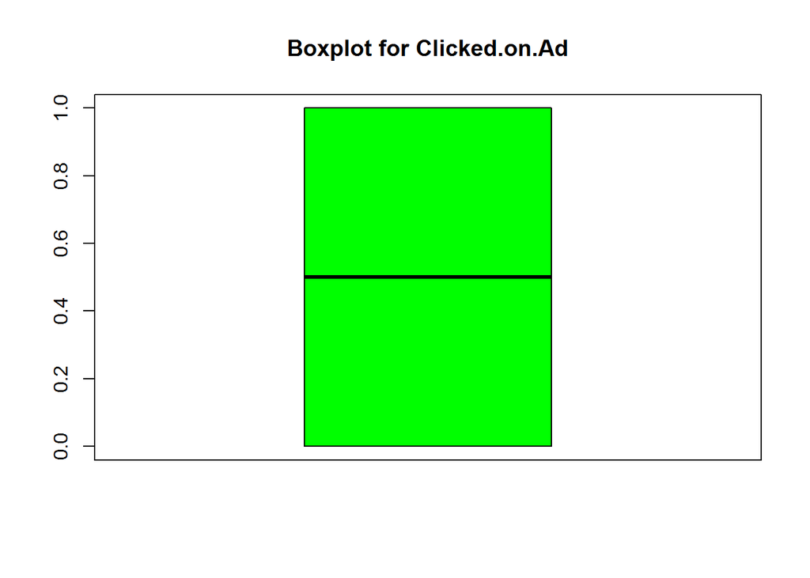

```r
boxplot(df$`Clicked.on.Ad`,main="Boxplot for Clicked.on.Ad",col = "green")
```

Area.income was the only column that had outliers

```r
#df$Timestamp<- as.Date(df$Timestamp,format = "%Y-%m-%s-%h-%m-%s")
#Checking for the changes
sapply(df,class)
```

```
## Daily.Time.Spent.on.Site                      Age              Area.Income
##                "numeric"                "integer"                "numeric"
##     Daily.Internet.Usage            Ad.Topic.Line                     City
##                "numeric"              "character"              "character"
##                     Male                  Country                Timestamp
##                "integer"              "character"              "character"
##            Clicked.on.Ad
##                "integer"
```

```r
head(df)
```

```
##   Daily.Time.Spent.on.Site Age Area.Income Daily.Internet.Usage
## 1                    68.95  35    61833.90               256.09
## 2                    80.23  31    68441.85               193.77
## 3                    69.47  26    59785.94               236.50
## 4                    74.15  29    54806.18               245.89
## 5                    68.37  35    73889.99               225.58
## 6                    59.99  23    59761.56               226.74
##                           Ad.Topic.Line           City Male    Country
## 1    Cloned 5thgeneration orchestration    Wrightburgh    0    Tunisia
## 2    Monitored national standardization      West Jodi    1      Nauru
## 3      Organic bottom-line service-desk       Davidton    0 San Marino
## 4 Triple-buffered reciprocal time-frame West Terrifurt    1      Italy
## 5         Robust logistical utilization   South Manuel    0    Iceland
## 6       Sharable client-driven software      Jamieberg    1     Norway
##             Timestamp Clicked.on.Ad
## 1 2016-03-27 00:53:11             0
## 2 2016-04-04 01:39:02             0
## 3 2016-03-13 20:35:42             0
## 4 2016-01-10 02:31:19             0
## 5 2016-06-03 03:36:18             0
## 6 2016-05-19 14:30:17             0
```

## *4. Univariate Analysis*

### *4.1. Measures of central Tendency*

#### *4.1.1. Mean*

```r
print("The mean for numeric variables is:")
```

```
## [1] "The mean for numeric variables is:"
```

```r
colMeans(df[sapply(df,is.numeric)])
```

```
## Daily.Time.Spent.on.Site                      Age              Area.Income
##                  65.0002                  36.0090               55000.0001
##     Daily.Internet.Usage                     Male            Clicked.on.Ad
##                 180.0001                   0.4810                   0.5000
```

#### *4.1.2. Median*

```r
cat("The median for daily time spent on site is",median(df$Daily.Time.Spent.on.Site))
```

```
## The median for daily time spent on site is 68.215
```

```r
cat("\n")
```

```r
cat("The median for age is",median(df$Age))
```

```
## The median for age is 35
```

```r
cat("\n")
```

```r
cat("The median for Area.Income is",median(df$Area.Income))
```

```
## The median for Area.Income is 57012.3
```

```r
cat("\n")
```

```r
cat("The median for daily Internet Usage is",median(df$Daily.Internet.Usage))
```

```
## The median for daily Internet Usage is 183.13
```

```r
cat("\n")
```

```r
cat("The median for male is",median(df$Male))
```

```
## The median for male is 0
```

```r
cat("\n")
```

```r
cat("The median for Clicked on Ad",median(df$Clicked.on.Ad))
```

```
## The median for Clicked on Ad 0.5
```

#### *4.1.3. Mode*

```r
#Creating a function for the mode
getmode <- function(v) {
   uniqv <- unique(v)
   uniqv[which.max(tabulate(match(v, uniqv)))]
}
```

```r
cat("The mode for daily time spent on site is",getmode(df$Daily.Time.Spent.on.Site))
```

```
## The mode for daily time spent on site is 62.26
```

```r
cat("\n")
```

```r
cat("The mode for age is",getmode(df$Age))
```

```
## The mode for age is 31
```

```r
cat("\n")
```

```r
cat("The mode for Area.Income is",getmode(df$Area.Income))
```

```
## The mode for Area.Income is 61833.9
```

```r
cat("\n")
```

```r
cat("The mode for daily Internet Usage is",getmode(df$Daily.Internet.Usage))
```

```
## The mode for daily Internet Usage is 167.22
```

```r
cat("\n")
```

```r
cat("The mode for male is",getmode(df$Male))
```

```
## The mode for male is 0
```

```r
cat("\n")
```

```r
cat("The mode for Clicked on Ad",getmode(df$Clicked.on.Ad))
```

```
## The mode for Clicked on Ad 0
```

#### *4.1.4. Standard Deviation*

```r
cat("The standard deviation for daily time spent on site is",sd(df$`Daily.Time.Spent.on.Site`))
```

```
## The standard deviation for daily time spent on site is 15.85361
```

```r
cat("\n")
```

```r
cat("The standard deviation for age is",sd(df$`Age`))
```

```
## The standard deviation for age is 8.785562
```

```r
cat("\n")
```

```r
cat("The standard deviation for Area.Income is",sd(df$`Area.Income`))
```

```
## The standard deviation for Area.Income is 13414.63
```

```r
cat("\n")
```

```r
cat("The standard deviation for daily Internet Usage is",sd(df$`Daily.Internet.Usage`))
```

```
## The standard deviation for daily Internet Usage is 43.90234
```

```r
cat("\n")
```

```r
cat("The standard deviation for male is",sd(df$`Male`))
```

```
## The standard deviation for male is 0.4998889
```

```r
cat("\n")
```

```r
cat("The standard deviation for Clicked on Ad",sd(df$`Clicked.on.Ad`))
```

```
## The standard deviation for Clicked on Ad 0.5002502
```

#### *4.1.5. Variance*

```r
cat("The variance for daily time spent on site is",var(df$`Daily.Time.Spent.on.Site`))
```

```
## The variance for daily time spent on site is 251.3371
```

```r
cat("\n")
```

```r
cat("The variance for age is",var(df$`Age`))
```

```
## The variance for age is 77.18611
```

```r
cat("\n")
```

```r
cat("The variance for Area.Income is",var(df$`Area.Income`))
```

```
## The variance for Area.Income is 179952406
```

```r
cat("\n")
```

```r
cat("The variance for daily Internet Usage is",var(df$`Daily.Internet.Usage`))
```

```
## The variance for daily Internet Usage is 1927.415
```

```r
cat("\n")
```

```r
cat("The variance for male is",var(df$`Male`))
```

```
## The variance for male is 0.2498889
```

```r
cat("\n")
```

```r
cat("The variance for Clicked on Ad",var(df$`Clicked.on.Ad`))
```

```
## The variance for Clicked on Ad 0.2502503
```

### *4.2. Measures of Dispersion*

#### *4.2.1. Minimum*

```r
library(dplyr)
df %>% summarise_if(is.numeric,min)
```

```
##   Daily.Time.Spent.on.Site Age Area.Income Daily.Internet.Usage Male
## 1                     32.6  19     13996.5               104.78    0
##   Clicked.on.Ad
## 1             0
```

#### *4.2.2. Maximum*

```r
#Maximum of the columns
df %>% summarise_if(is.numeric,max)
```

```
##   Daily.Time.Spent.on.Site Age Area.Income Daily.Internet.Usage Male
## 1                    91.43  61     79484.8               269.96    1
##   Clicked.on.Ad
## 1             1
```

#### *4.2.3. Range*

```r
cat("The range for daily time spent on site is",range(df$`Daily.Time.Spent.on.Site`))
```

```
## The range for daily time spent on site is 32.6 91.43
```

```r
cat("\n")
```

```r
cat("The range for age is",range(df$`Age`))
```

```
## The range for age is 19 61
```

```r
cat("\n")
```

```r
cat("The range for Area.Income is",range(df$`Area.Income`))
```

```
## The range for Area.Income is 13996.5 79484.8
```

```r
cat("\n")
```

```r
cat("The range for daily Internet Usage is",range(df$`Daily.Internet.Usage`))
```

```
## The range for daily Internet Usage is 104.78 269.96
```

```r
cat("\n")
```

```r
cat("The range for male is",range(df$`Male`))
```

```
## The range for male is 0 1
```

```r
cat("\n")
```

```r
cat("The range for Clicked on Ad",range(df$`Clicked.on.Ad`))
```

```
## The range for Clicked on Ad 0 1
```

#### *4.2.4. Quantile*

```r
cat("The Quantile for daily time spent on site is",quantile(df$`Daily.Time.Spent.on.Site`))
```

```
## The Quantile for daily time spent on site is 32.6 51.36 68.215 78.5475 91.43
```

```r
cat("\n")
```

```r
cat("The Quantile for age is",quantile(df$`Age`))
```

```
## The Quantile for age is 19 29 35 42 61
```

```r
cat("\n")
```

```r
cat("The Quantile for Area.Income is",quantile(df$`Area.Income`))
```

```
## The Quantile for Area.Income is 13996.5 47031.8 57012.3 65470.64 79484.8
```

```r
cat("\n")
```

```r
cat("The Quantile for daily Internet Usage is",quantile(df$`Daily.Internet.Usage`))
```

```
## The Quantile for daily Internet Usage is 104.78 138.83 183.13 218.7925 269.96
```

```r
cat("\n")
```

```r
cat("The Quantile for male is",quantile(df$`Male`))
```

```
## The Quantile for male is 0 0 0 1 1
```

```r
cat("\n")
```

```r
cat("The Quantile for Clicked on Ad",quantile(df$`Clicked.on.Ad`))
```

```
## The Quantile for Clicked on Ad 0 0 0.5 1 1
```

```r
summary(df)
```

```
##  Daily.Time.Spent.on.Site      Age         Area.Income    Daily.Internet.Usage
##  Min.   :32.60            Min.   :19.00   Min.   :13996   Min.   :104.8
##  1st Qu.:51.36            1st Qu.:29.00   1st Qu.:47032   1st Qu.:138.8
##  Median :68.22            Median :35.00   Median :57012   Median :183.1
##  Mean   :65.00            Mean   :36.01   Mean   :55000   Mean   :180.0
##  3rd Qu.:78.55            3rd Qu.:42.00   3rd Qu.:65471   3rd Qu.:218.8
##  Max.   :91.43            Max.   :61.00   Max.   :79485   Max.   :270.0
##  Ad.Topic.Line          City                Male         Country
##  Length:1000        Length:1000        Min.   :0.000   Length:1000
##  Class :character   Class :character   1st Qu.:0.000   Class :character
##  Mode  :character   Mode  :character   Median :0.000   Mode  :character
##                                        Mean   :0.481
##                                        3rd Qu.:1.000
##                                        Max.   :1.000
##   Timestamp         Clicked.on.Ad
##  Length:1000        Min.   :0.0
##  Class :character   1st Qu.:0.0
##  Mode  :character   Median :0.5
##                     Mean   :0.5
##                     3rd Qu.:1.0
##                     Max.   :1.0
```

#### *Barcharts*

```r
frequency <- table(df$Male)
frequency
```

```
##
##   0   1
## 519 481
```

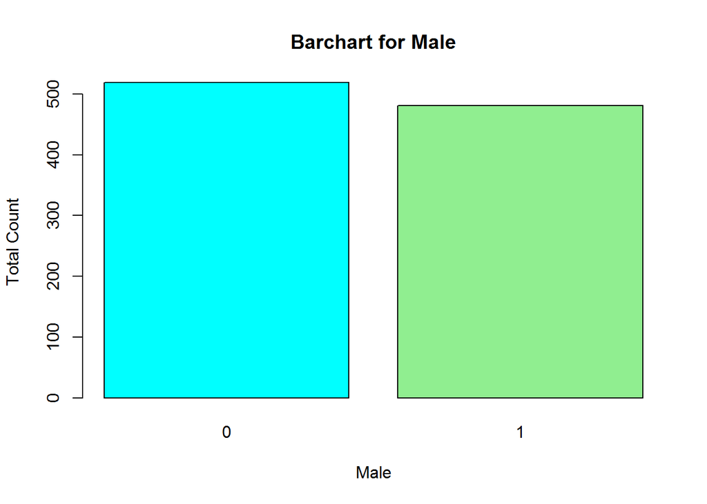

```r
barplot(frequency,col=c("Cyan","lightgreen"),main="Barchart for Male",xlab = "Male",ylab = "Total Count")
```

```r
frequency <- table(df$`Clicked.on.Ad`)
frequency
```

```
##
##   0   1
## 500 500
```

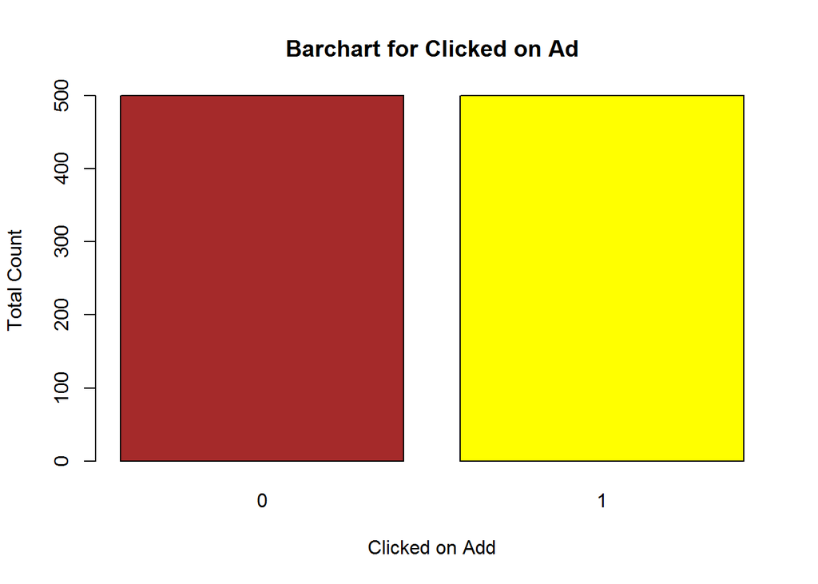

```r
barplot(frequency,col=c("Brown","yellow"),main="Barchart for Clicked on Ad",xlab = "Clicked on Add",ylab = "Total Count")
```

```r
frequency <- table(df$Age)
frequency
```

```
##
## 19 20 21 22 23 24 25 26 27 28 29 30 31 32 33 34 35 36 37 38 39 40 41 42 43 44
##  6  6  6 13 19 21 27 37 33 48 48 39 60 38 43 39 39 50 36 37 30 36 32 26 23 21
## 45 46 47 48 49 50 51 52 53 54 55 56 57 58 59 60 61
## 30 18 13 16 18 20 12 15 10  9  7  2  6  4  2  4  1
```

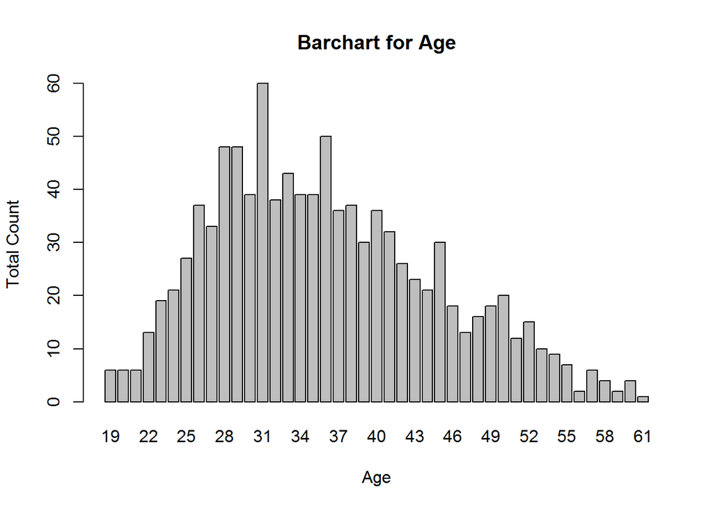

```r
barplot(frequency,main="Barchart for Age",xlab = "Age",ylab = "Total Count")
```

* The mean Age is 36. * The median age is 35 * The respondents on the website are mostly 25-40years old.

#### *Histograms*

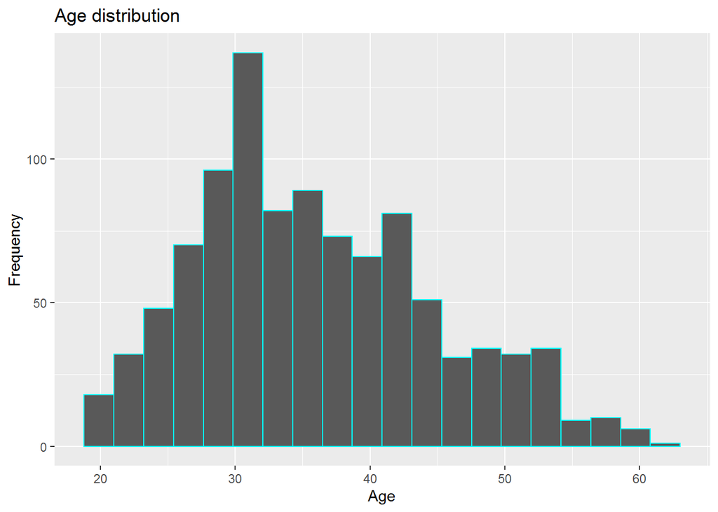

```r
library(ggplot2)
ggplot(df, aes(Age)) + geom_histogram(bins = 20, color = 'cyan') +
    labs(title = 'Age distribution', x = 'Age', y = 'Frequency')
```

* The Age distribution is rightly skewed

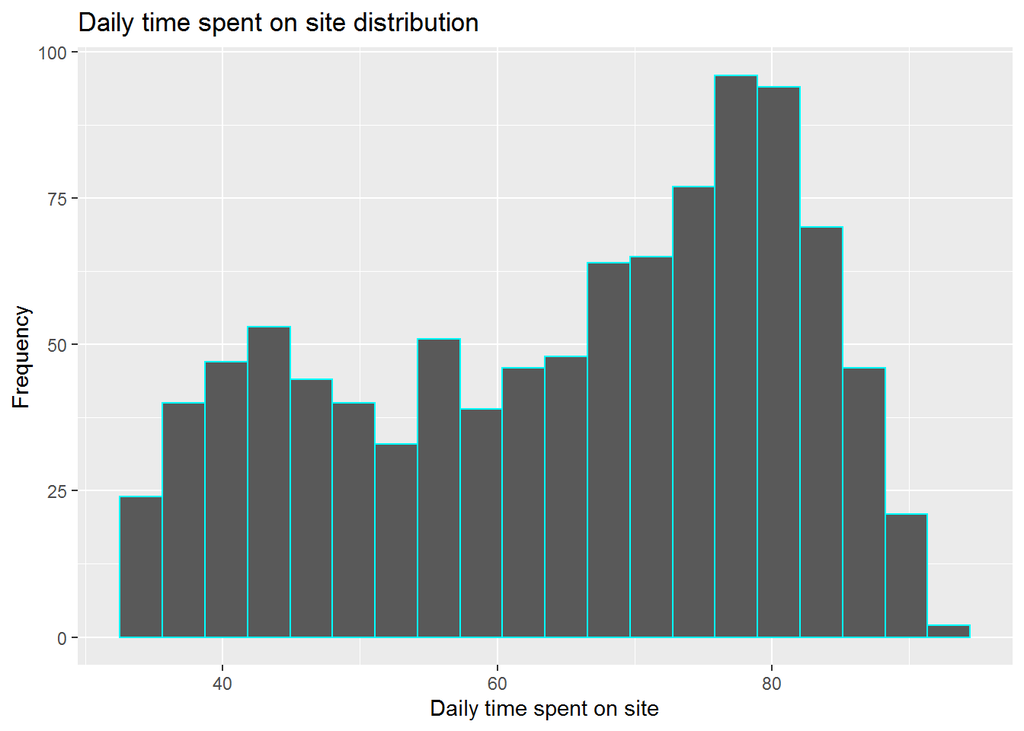

```r
ggplot(df, aes(`Daily.Time.Spent.on.Site`)) + geom_histogram(bins = 20, color = 'cyan') +
    labs(title = 'Daily time spent on site distribution', x = 'Daily time spent on site', y = 'Frequency')
```

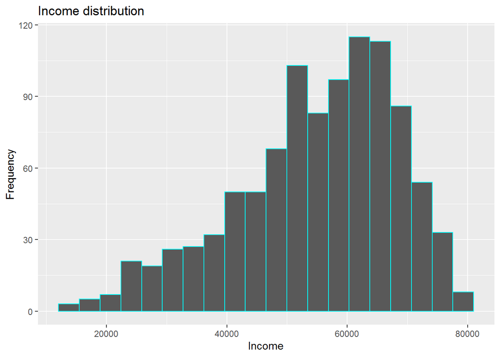

```r
ggplot(df, aes(`Area.Income`)) + geom_histogram(bins = 20, color = 'cyan') +
    labs(title = 'Income distribution', x = 'Income', y = 'Frequency')
```

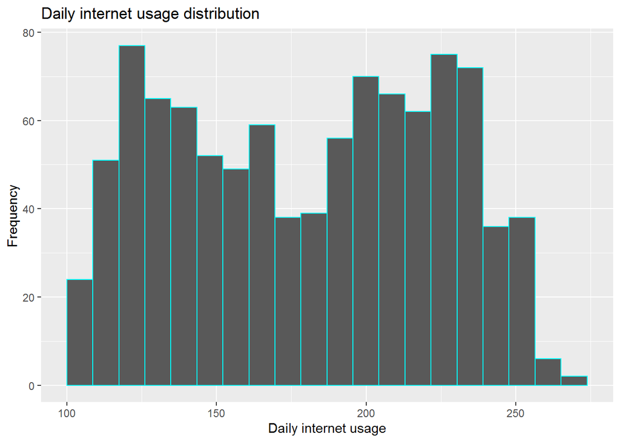

```r
ggplot(df, aes(`Daily.Internet.Usage`)) + geom_histogram(bins = 20, color = 'cyan') +
    labs(title = 'Daily internet usage distribution', x = 'Daily internet usage', y = 'Frequency')
```

### **Bivariate Analysis**

#### **Covariance**

```r
covariance <- cov(df[sapply(df,is.numeric)])
covariance
```

```
##                          Daily.Time.Spent.on.Site           Age   Area.Income
## Daily.Time.Spent.on.Site              251.3370949 -4.617415e+01  6.613081e+04
## Age                                   -46.1741459  7.718611e+01 -2.152093e+04
## Area.Income                         66130.8109082 -2.152093e+04  1.799524e+08
## Daily.Internet.Usage                  360.9918827 -1.416348e+02  1.987625e+05
## Male                                   -0.1501864 -9.242142e-02  8.867509e+00
## Clicked.on.Ad                          -5.9331431  2.164665e+00 -3.195989e+03
##                          Daily.Internet.Usage        Male Clicked.on.Ad
## Daily.Time.Spent.on.Site         3.609919e+02 -0.15018639 -5.933143e+00
## Age                             -1.416348e+02 -0.09242142  2.164665e+00
## Area.Income                      1.987625e+05  8.86750903 -3.195989e+03
## Daily.Internet.Usage             1.927415e+03  0.61476667 -1.727409e+01
## Male                             6.147667e-01  0.24988889 -9.509510e-03
## Clicked.on.Ad                   -1.727409e+01 -0.00950951  2.502503e-01
```

#### **Correlation**

```r
install.packages("corrplot")
library(corrplot)
#Correlation of all numeric variables
df.cor = cor(df[sapply(df,is.numeric)],method = c("spearman"))
df.cor
```

```
##                          Daily.Time.Spent.on.Site         Age Area.Income
## Daily.Time.Spent.on.Site               1.00000000 -0.31686155  0.28313439
## Age                                   -0.31686155  1.00000000 -0.13595396
## Area.Income                            0.28313439 -0.13595396  1.00000000
## Daily.Internet.Usage                   0.51410805 -0.37086395  0.33916021
## Male                                  -0.01592213 -0.02315468 -0.01436909
## Clicked.on.Ad                         -0.74487253  0.48633733 -0.46722440
##                          Daily.Internet.Usage        Male Clicked.on.Ad
## Daily.Time.Spent.on.Site           0.51410805 -0.01592213   -0.74487253
## Age                               -0.37086395 -0.02315468    0.48633733
## Area.Income                        0.33916021 -0.01436909   -0.46722440
## Daily.Internet.Usage               1.00000000  0.02820432   -0.77660702
## Male                               0.02820432  1.00000000   -0.03802747
## Clicked.on.Ad                     -0.77660702 -0.03802747    1.00000000
```

#### **correlation plot**

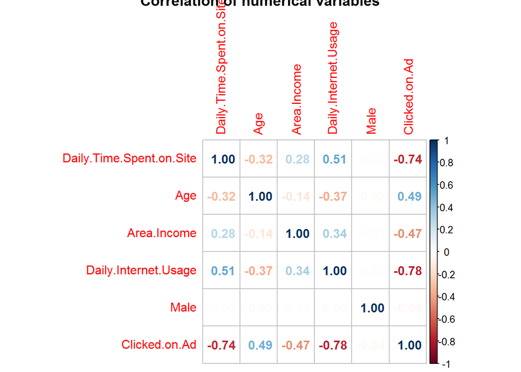

```r
corrplot(df.cor,method="number",main="Correlation of numerical variables")
```

#### **Heat Map**

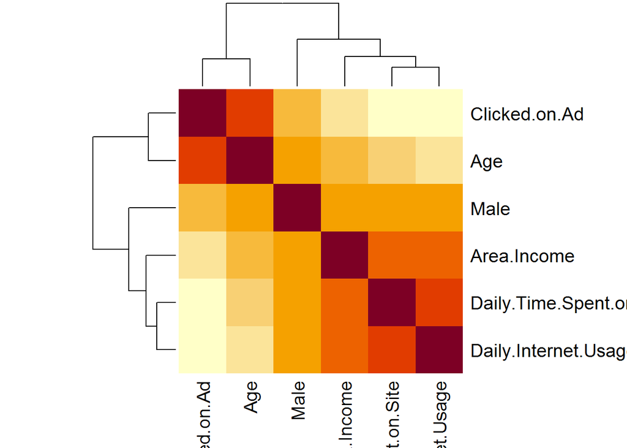

```r
heatmap(x=df.cor,symm = TRUE,method="number")
```

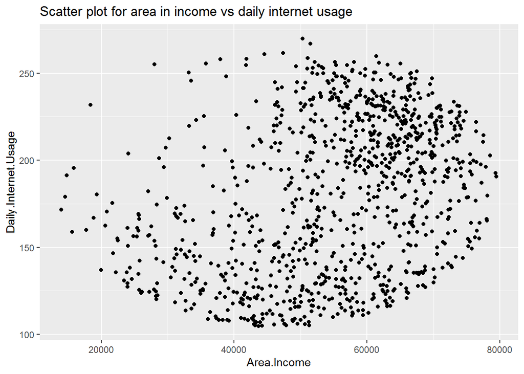

```r
#Scatter plot for area in income vs daily internet usage
ggplot(df, aes(x = `Area.Income`, y = `Daily.Internet.Usage` )) +
  geom_point() + labs(title = 'Scatter plot for area in income vs daily internet usage')
```

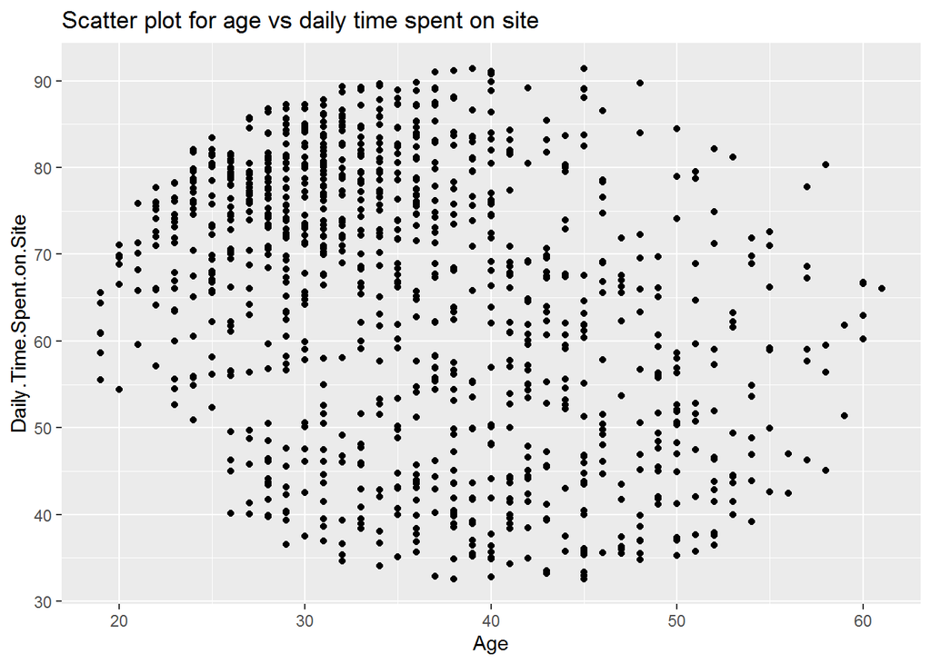

```r
#Scatter plot for age vs daily time spent on site
ggplot(df, aes(x = Age, y = `Daily.Time.Spent.on.Site` )) +
  geom_point() + labs(title = 'Scatter plot for age vs daily time spent on site')
```

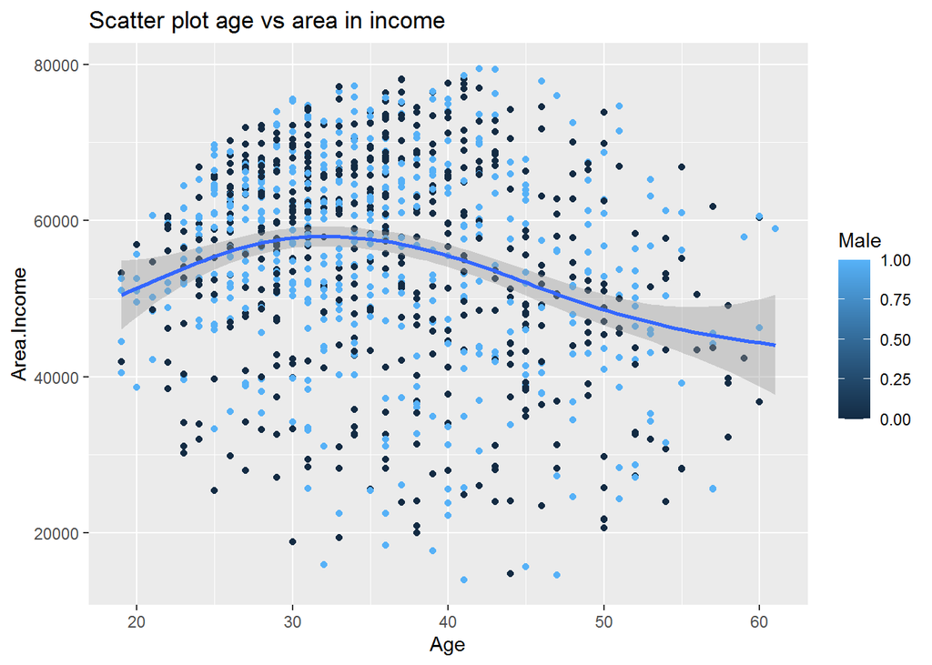

```r
#Scatter plot for age vs area in income
ggplot(df, aes(x = Age, y = `Area.Income`, col=Male),add ="reg.line",conf.int = TRUE) +geom_point()+geom_smooth()+ labs(title = 'Scatter plot age vs area in income')
```

```r
library(dplyr)
```

```r
df %>% group_by(Country, `Daily.Internet.Usage`)%>% head(10)%>% arrange(desc(`Daily.Internet.Usage`))
```

```
## # A tibble: 10 x 10
## # Groups:   Country, Daily.Internet.Usage [10]
##    Daily.Time.Spen~   Age Area.Income Daily.Internet.~ Ad.Topic.Line City   Male
##               <dbl> <int>       <dbl>            <dbl> <chr>         <chr> <int>
##  1             69.0    35      61834.             256. Cloned 5thge~ Wrig~     0
##  2             74.2    29      54806.             246. Triple-buffe~ West~     1
##  3             69.5    26      59786.             236. Organic bott~ Davi~     0
##  4             60.0    23      59762.             227. Sharable cli~ Jami~     1
##  5             68.4    35      73890.             226. Robust logis~ Sout~     0
##  6             74.5    30      68862              222. Configurable~ West~     1
##  7             88.9    33      53853.             208. Enhanced ded~ Bran~     0
##  8             80.2    31      68442.             194. Monitored na~ West~     1
##  9             69.9    20      55642.             184. Mandatory ho~ Rami~     1
## 10             66      48      24593.             132. Reactive loc~ Port~     1
## # ... with 3 more variables: Country <chr>, Timestamp <chr>,
## #   Clicked.on.Ad <int>
```

```r
df %>% group_by(Country, `Daily.Time.Spent.on.Site`)%>% head(10)%>% arrange(desc(`Daily.Time.Spent.on.Site`))
```

```
## # A tibble: 10 x 10
## # Groups:   Country, Daily.Time.Spent.on.Site [10]
##    Daily.Time.Spen~   Age Area.Income Daily.Internet.~ Ad.Topic.Line City   Male
##               <dbl> <int>       <dbl>            <dbl> <chr>         <chr> <int>
##  1             88.9    33      53853.             208. Enhanced ded~ Bran~     0
##  2             80.2    31      68442.             194. Monitored na~ West~     1
##  3             74.5    30      68862              222. Configurable~ West~     1
##  4             74.2    29      54806.             246. Triple-buffe~ West~     1
##  5             69.9    20      55642.             184. Mandatory ho~ Rami~     1
##  6             69.5    26      59786.             236. Organic bott~ Davi~     0
##  7             69.0    35      61834.             256. Cloned 5thge~ Wrig~     0
##  8             68.4    35      73890.             226. Robust logis~ Sout~     0
##  9             66      48      24593.             132. Reactive loc~ Port~     1
## 10             60.0    23      59762.             227. Sharable cli~ Jami~     1
## # ... with 3 more variables: Country <chr>, Timestamp <chr>,
## #   Clicked.on.Ad <int>
```